# TZ Gaming: Optimal Targeting of Mobile Ads

- Name: Ziyuan Yan
- GitLab id: “rsm-ziy062”

## Setup

Please complete this Rmarkdown document by answering the questions in `tz-gaming.pdf` on Canvas (week5/). Create a Notebook/HTML file with all your results and comments and push both the Rmarkdown and HTML file to GitLab when you are done. All results MUST be reproducible (i.e., the TA and I must be able to recreate the HTML from the Rmarkdown file without changes or errors).

> Note: If you use Rstudio’s git tab to push your submission to GitLab you may see warnings or messages when pushing the HTML file because of its size. To avoid these messages you can also push your files to GitLab by using GitGadget’s “Sync” tab (i.e., Commit your changes and then Push).

```r
library(radiant)
library(tidyverse)
```

```r
## loading the data - this dataset must NOT be changed
tz_gaming <- readr::read_rds("data/tz_gaming.rds")
radiant.data::describe(tz_gaming)
```

[output not shown]

```r
training <- tz_gaming %>%
  filter(training == 'train')

test <- tz_gaming %>%
  filter(training == 'test')
```

## Part I: Logistic Regression

#### a.

```r
click_logit <- radiant.model::logistic(
  training,
  rvar = "click",
  evar = c("impup", "clup", "ctrup", "impua", "clua", "ctrua", "imput", "clut", "ctrut", "imppat", "clpat", "ctrpat"),
  lev = "yes"
)

summary(click_logit)
```

```
Logistic regression (GLM)
Data                 : training
Response variable    : click
Level                : yes in click
Explanatory variables: impup, clup, ctrup, impua, clua, ctrua, imput, clut, ctrut, imppat, clpat, ctrpat
Null hyp.: there is no effect of x on click
Alt. hyp.: there is an effect of x on click

                OR coefficient std.error z.value p.value
 (Intercept)            -4.963     0.087 -56.843  < .001 ***
 impup       1.000       0.000     0.000   0.324   0.746
 clup        1.010       0.010     0.004   2.743   0.006 **
 ctrup       1.030       0.030     0.004   6.915  < .001 ***
 impua       0.986      -0.014     0.002  -5.920  < .001 ***
 clua        1.046       0.045     0.070   0.635   0.525
 ctrua       1.008       0.008     0.003   2.754   0.006 **
 imput       0.995      -0.005     0.001  -4.182  < .001 ***
 clut        1.254       0.226     0.021  10.582  < .001 ***
 ctrut       1.031       0.030     0.003   9.233  < .001 ***
 imppat      1.000      -0.000     0.000  -3.583  < .001 ***
 clpat       1.001       0.001     0.000   4.331  < .001 ***
 ctrpat      1.359       0.307     0.039   7.820  < .001 ***

Signif. codes:  0 '***' 0.001 '**' 0.01 '*' 0.05 '.' 0.1 ' ' 1

Pseudo R-squared: 0.147
Log-likelihood: -3780.032, AIC: 7586.063, BIC: 7708.001
Chi-squared: 1300.361 df(12), p.value < .001
Nr obs: 87,535
```

#### b.

##### Explanatory variables that are statistically significant: clut, ctrup, impua, ctrua, imput, clut, ctrut, imppat, clpat, ctrpat. Because their p-values are < 0.05, the significant level.

##### The variables that seem to be most important: ctrpat, becuase the odds-ratio is the lagest. clut is also important.

##### (1) an interpretation of the odds-ratios estimated for each of the explanatory variables:

###### Keeping all other variables in the model constant, when clut increases by 1 unit, the odds of the adds being clicked increase by a factor of 1.254.

###### Keeping all other variables in the model constant, when ctrpat increases by 1 unit, the odds of the adds being clicked increase by a factor of 1.359.

###### Among all of these, clup, ctrup, clua, ctrua, clut, ctrut, clpat and ctrpat increases the odds of the adds being clicked. ctrpat has the largest impact.

##### (2) an evaluation of the model as a whole:

###### Most of the variables in the model has p-value < 0.001, general p-value for the whole model is also < 0.001, which means that most of the explanatory variables are statistically significant.

## Part II: Decile Analysis of Logistic Regression Results

#### a.

```r
pred_test = predict(click_logit, test, type="response")

pred_test <- pred_test %>%
  mutate(dec_logit = xtile(pred_test$Prediction, n = 10, rev = TRUE)) %>%
  select("Prediction", "2.5%", "97.5%", "dec_logit")

test_IIa <- cbind(test, pred_test)
```

#### b.

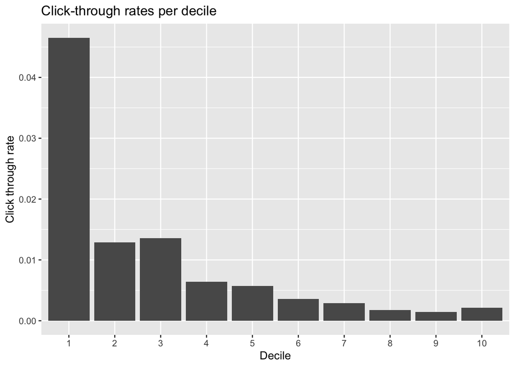

```r
b <- test_IIa %>%
  group_by(dec_logit) %>%
  summarise(click_through_rate = sum(click == "yes")/n())

ggplot(b, aes(x = as.factor(dec_logit), y = click_through_rate)) +
  geom_bar(stat = 'identity') +
  labs(title = "Click-through rates per decile", x = "Decile", y = "Click through rate")
```

#### c.

```r
dec_df_logit <- test_IIa %>%
  group_by(dec_logit) %>%
  summarise(num_impression = n(),
            num_clicks = sum(click == "yes"),
            click_through_rate = sum(click == "yes")/n())
```

#### d.

```r
d <- radiant.model::logistic(
  training,
  rvar = "click",
  evar = c("imppat", "clpat", "ctrpat"),
  lev = "yes",
  check = "standardize"
)
summary(d)
```

```
Logistic regression (GLM)
Data                 : training
Response variable    : click
Level                : yes in click
Explanatory variables: imppat, clpat, ctrpat
Null hyp.: there is no effect of x on click
Alt. hyp.: there is an effect of x on click
**Standardized odds-ratios and coefficients shown (2 X SD)**

                 OR coefficient std.error  z.value p.value
 (Intercept)             -4.915     0.043 -114.229  < .001 ***
 imppat       0.134      -2.010     0.419   -4.802  < .001 ***
 clpat       11.688       2.459     0.430    5.713  < .001 ***
 ctrpat       2.025       0.705     0.051   13.933  < .001 ***

Signif. codes:  0 '***' 0.001 '**' 0.01 '*' 0.05 '.' 0.1 ' ' 1

Pseudo R-squared: 0.035
Log-likelihood: -4273.088, AIC: 8554.176, BIC: 8591.695
Chi-squared: 314.248 df(3), p.value < .001
Nr obs: 87,535
```

#### e.

###### imppat – Number of past impressions that showed the TZ ad in the app in the hour

###### clpat – Number of past clicks the TZ ad has received in the app in the hour

###### The high correlation (0.97) between imppat and clpat makes sense, because the more TZ adds that are shown in impressions, the more clicks TZ will receive.

###### Different approaches to deal with highly correlated explanatory variables: 1. Check that there is no dummy variable trap. 2. Drop one of the variables that is highly correlated with the other. 3. Combine two highly correlated variables. 4. Standardize the independent variables.

```r
e <- radiant.model::logistic(
  training,
  rvar = "click",
  evar = c("imppat", "ctrpat"),
  lev = "yes",
  check = "standardize"
)
summary(e)
```

```
Logistic regression (GLM)
Data                 : training
Response variable    : click
Level                : yes in click
Explanatory variables: imppat, ctrpat
Null hyp.: there is no effect of x on click
Alt. hyp.: there is an effect of x on click
**Standardized odds-ratios and coefficients shown (2 X SD)**

                OR coefficient std.error  z.value p.value
 (Intercept)            -4.859     0.040 -121.262  < .001 ***
 imppat      1.412       0.345     0.063    5.460  < .001 ***
 ctrpat      2.246       0.809     0.044   18.422  < .001 ***

Signif. codes:  0 '***' 0.001 '**' 0.01 '*' 0.05 '.' 0.1 ' ' 1

Pseudo R-squared: 0.031
Log-likelihood: -4290.903, AIC: 8587.805, BIC: 8615.945
Chi-squared: 278.619 df(2), p.value < .001
Nr obs: 87,535
```

###### When I remove clpat from the model, the estimated (standardized) odd-ratio for imppat increases significantly. In fact, coefficient changed from negative to positive. As we removed the variable that is highly correlated with imppat, the result for impaat would definitely change.

#### f.

```r
f <- radiant.model::logistic(
  training,
  rvar = "click",
  evar = c("time_fct", "app", "imppat", "clpat", "ctrpat"),
  lev = "yes"
)
summary(f)
```

```
Logistic regression (GLM)
Data                 : training
Response variable    : click
Level                : yes in click
Explanatory variables: time_fct, app, imppat, clpat, ctrpat
Null hyp.: there is no effect of x on click
Alt. hyp.: there is an effect of x on click

                OR coefficient std.error z.value p.value
 (Intercept)            -4.424     0.284 -15.575  < .001 ***
 time_fct|2  0.588      -0.532     0.323  -1.644   0.100
 time_fct|3  0.693      -0.367     0.461  -0.795   0.426
 time_fct|4  0.000     -14.834   487.743  -0.030   0.976
 time_fct|5  0.000     -14.860   635.984  -0.023   0.981
 time_fct|6  0.359      -1.025     1.027  -0.999   0.318
 time_fct|7  1.220       0.199     0.438   0.453   0.650
 time_fct|8  1.135       0.127     0.309   0.411   0.681
 time_fct|9  1.063       0.061     0.299   0.203   0.839
 time_fct|10 0.843      -0.170     0.303  -0.561   0.575
 time_fct|11 0.637      -0.451     0.288  -1.565   0.118
 time_fct|12 0.834      -0.181     0.292  -0.620   0.535
 time_fct|13 0.535      -0.626     0.306  -2.047   0.041 *
 time_fct|14 0.982      -0.018     0.257  -0.069   0.945
 time_fct|15 0.840      -0.174     0.272  -0.639   0.523
 time_fct|16 0.874      -0.135     0.279  -0.483   0.629
 time_fct|17 0.864      -0.146     0.296  -0.493   0.622
 time_fct|18 0.942      -0.060     0.286  -0.208   0.835
 time_fct|19 1.178       0.164     0.251   0.651   0.515
 time_fct|20 1.188       0.172     0.247   0.698   0.485
 time_fct|21 0.782      -0.245     0.261  -0.942   0.346
 time_fct|22 0.933      -0.069     0.259  -0.267   0.789
 time_fct|23 0.993      -0.007     0.268  -0.025   0.980
 time_fct|24 1.134       0.125     0.258   0.486   0.627
 app|app2    0.136      -1.997     0.351  -5.681  < .001 ***
 app|app3    0.187      -1.675     1.016  -1.649   0.099 .
 app|app4    0.487      -0.719     0.359  -2.004   0.045 *
 app|app5    0.413      -0.883     1.011  -0.874   0.382
 app|app6    1.007       0.007     0.216   0.034   0.973
 app|app7    0.708      -0.346     1.019  -0.340   0.734
 app|app8    0.000     -15.110   807.821  -0.019   0.985
```

[output cut: 36 more lines]

```
 app|app45   1.920       0.652     0.604   1.079   0.281
 app|app46   0.466      -0.763     1.020  -0.748   0.455
 app|app47   0.406      -0.902     1.012  -0.891   0.373
 app|app48   0.000     -15.045  1178.615  -0.013   0.990
 app|app49   0.259      -1.349     1.019  -1.324   0.185
 imppat      1.000      -0.000     0.000  -1.131   0.258
 clpat       1.001       0.001     0.001   1.135   0.256
 ctrpat      1.077       0.075     0.117   0.637   0.524

Signif. codes:  0 '***' 0.001 '**' 0.01 '*' 0.05 '.' 0.1 ' ' 1

Pseudo R-squared: 0.056
Log-likelihood: -4180.646, AIC: 8511.292, BIC: 9214.776
Chi-squared: 499.132 df(74), p.value < .001
Nr obs: 87,535
```

###### The odds ratio are different in the two models because this model is not standardized and we added to more variables. Since imppat, clpat ad ctrpat are all correlated with the two new variables, the odds ratios are different.

## Part III: Lift and Gains

#### a.

```r
lift <- dec_df_logit %>%
  mutate(res_rate = num_clicks/num_impression,
         lift = res_rate/mean(res_rate),
         cum_num_impression = cumsum(num_impression),
         cum_num_clicks = cumsum(num_clicks),
         cum_res_rate = cum_num_clicks/cum_num_impression,
         cum_lift = cum_res_rate/mean(res_rate)) %>%
  select(dec_logit, lift, cum_lift)
```

#### b.

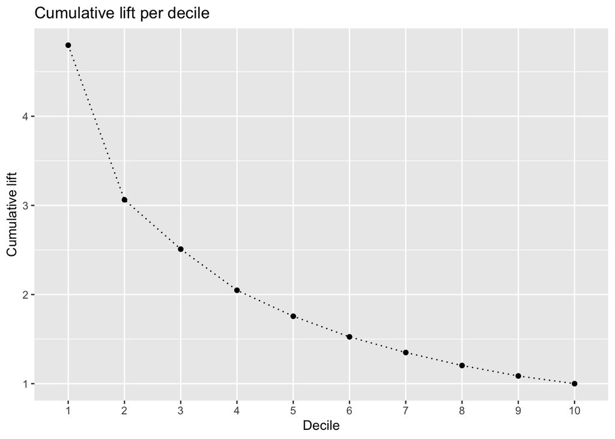

```r
ggplot(lift, aes(x = as.factor(dec_logit), y = cum_lift)) +
  geom_point() +
  geom_line(group = 1, linetype = "dotted") +
  labs(title = "Cumulative lift per decile", x = "Decile", y = "Cumulative lift")
```

#### c.

```r
gains <- dec_df_logit %>%
  mutate(cum_num_clicks = cumsum(num_clicks),
         gains = num_clicks/sum(num_clicks),
         cum_gains = cum_num_clicks/sum(num_clicks)) %>%
  select(dec_logit, gains, cum_gains)

zero <- c(0, 0, 0)
gains <- rbind(zero, gains)
```

#### d.

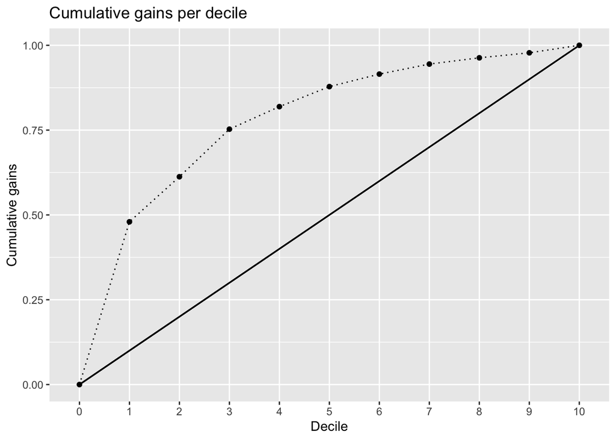

```r
ggplot(gains, aes(x = as.factor(dec_logit), y = cum_gains)) +
  geom_point() +
  geom_line(group = 1, linetype = "dotted") +
  geom_segment(aes(x = 1, y = 0, xend = 11, yend = 1)) +
  labs(title = "Cumulative gains per decile", x = "Decile", y = "Cumulative gains")
```

## Part IV: Confusion matrix

#### a.

```r
breakeven <- (10/1000)/(25*0.05)

IV <- test_IIa %>%
  mutate(target = ifelse(Prediction > breakeven, 1, 0),
         click_numeric = ifelse(click == "yes", 1, 0),
         TP = ifelse(target == 1 & click_numeric == 1, 1, 0),
         TN = ifelse(target == 0 & click_numeric == 0, 1, 0),
         FP = ifelse(target == 1 & click_numeric == 0, 1, 0),
         FN = ifelse(target == 0 & click_numeric == 1, 1, 0))

TP <- sum(IV$TP)
TN <- sum(IV$TN)
FP <- sum(IV$FP)
FN <- sum(IV$FN)

confusion <- data.frame(matrix(NA, nrow = 2, ncol = 2))
rownames(confusion) <- c("Pos_Actual", "Neg_Actual")
colnames(confusion) <- c("Pos_Predict", "Neg_Predict")
confusion[1, 1] = TP
confusion[1, 2] = FN
confusion[2, 1] = FP
confusion[2, 2] = TN

accuracy <- (TP+TN)/(TP+TN+FP+FN)
```

#### b.

```r
IVb <- radiant.model::logistic(
  training,
  rvar = "click",
  evar = "rnd",
  lev = "yes"
)
summary(IVb)
```

```
Logistic regression (GLM)
Data                 : training
Response variable    : click
Level                : yes in click
Explanatory variables: rnd
Null hyp.: there is no effect of rnd on click
Alt. hyp.: there is an effect of rnd on click

                OR coefficient std.error  z.value p.value
 (Intercept)            -4.720     0.036 -130.660  < .001 ***
 rnd         0.965      -0.036     0.036   -0.986   0.324

Signif. codes:  0 '***' 0.001 '**' 0.01 '*' 0.05 '.' 0.1 ' ' 1

Pseudo R-squared: 0
Log-likelihood: -4429.726, AIC: 8863.451, BIC: 8882.211
Chi-squared: 0.973 df(1), p.value 0.324
Nr obs: 87,535
```

```r
pred_test_IVb = predict(IVb, test, type="response")
pred_test_IVb <- pred_test_IVb %>%
  select(Prediction)
test_IVb <- cbind(test, pred_test_IVb)

test_IVb <- test_IVb %>%
  mutate(target = ifelse(Prediction > breakeven, 1, 0),
         click_numeric = ifelse(click == "yes", 1, 0),
         TP = ifelse(target == 1 & click_numeric == 1, 1, 0),
         TN = ifelse(target == 0 & click_numeric == 0, 1, 0),
         FP = ifelse(target == 1 & click_numeric == 0, 1, 0),
         FN = ifelse(target == 0 & click_numeric == 1, 1, 0))

TP <- sum(test_IVb$TP)
TN <- sum(test_IVb$TN)
FP <- sum(test_IVb$FP)
FN <- sum(test_IVb$FN)

confusion_IVb <- data.frame(matrix(NA, nrow = 2, ncol = 2))
rownames(confusion_IVb) <- c("Pos_Actual", "Neg_Actual")
colnames(confusion_IVb) <- c("Pos_Predict", "Neg_Predict")
confusion_IVb[1, 1] = TP
confusion_IVb[1, 2] = FN
confusion_IVb[2, 1] = FP
confusion_IVb[2, 2] = TN

accuracy_IVb <- (TP+TN)/(TP+TN+FP+FN)
```

#### c.

###### Differences between the two matrices: confusion IBv has extremely high FP, FN = 0 and very low TN. It basically predict impression as being clicked.

###### Based on the confusion matrix, the model in I.a is better because accuracy is higher, TN is higher, and FP is lower. In this case the company is not posting too many adds and wasting money.

#### d.

```r
IV_0.5 <- test_IIa %>%
  mutate(target = ifelse(Prediction > 0.5, 1, 0),
         click_numeric = ifelse(click == "yes", 1, 0),
         TP = ifelse(target == 1 & click_numeric == 1, 1, 0),
         TN = ifelse(target == 0 & click_numeric == 0, 1, 0),
         FP = ifelse(target == 1 & click_numeric == 0, 1, 0),
         FN = ifelse(target == 0 & click_numeric == 1, 1, 0))

TP <- sum(IV_0.5$TP)
TN <- sum(IV_0.5$TN)
FP <- sum(IV_0.5$FP)
FN <- sum(IV_0.5$FN)

confusion_0.5 <- data.frame(matrix(NA, nrow = 2, ncol = 2))
rownames(confusion_0.5) <- c("Pos_Actual", "Neg_Actual")
colnames(confusion_0.5) <- c("Pos_Predict", "Neg_Predict")
confusion_0.5[1, 1] = TP
confusion_0.5[1, 2] = FN
confusion_0.5[2, 1] = FP
confusion_0.5[2, 2] = TN

accuracy_0.5 <- (TP+TN)/(TP+TN+FP+FN)
```

```r
test_IVb_0.5 <- test_IVb %>%
  mutate(target = ifelse(Prediction > 0.5, 1, 0),
         click_numeric = ifelse(click == "yes", 1, 0),
         TP = ifelse(target == 1 & click_numeric == 1, 1, 0),
         TN = ifelse(target == 0 & click_numeric == 0, 1, 0),
         FP = ifelse(target == 1 & click_numeric == 0, 1, 0),
         FN = ifelse(target == 0 & click_numeric == 1, 1, 0))

TP <- sum(test_IVb_0.5$TP)
TN <- sum(test_IVb_0.5$TN)
FP <- sum(test_IVb_0.5$FP)
FN <- sum(test_IVb_0.5$FN)

confusion_IVb_0.5 <- data.frame(matrix(NA, nrow = 2, ncol = 2))
rownames(confusion_IVb_0.5) <- c("Pos_Actual", "Neg_Actual")
colnames(confusion_IVb_0.5) <- c("Pos_Predict", "Neg_Predict")
confusion_IVb_0.5[1, 1] = TP
confusion_IVb_0.5[1, 2] = FN
confusion_IVb_0.5[2, 1] = FP
confusion_IVb_0.5[2, 2] = TN

accuracy_IVb_0.5 <- (TP+TN)/(TP+TN+FP+FN)
```

###### Similarities between the two matrices: Both have similar FN and TN.

###### Differences between the two matrices: confusion_IVb_0.5 has TP = 0 and PF = 0. It basically predict impression as not being clicked. It also has a slightly higher accuracy.

###### Based on the confusion matrix, the model in I.a is still better. Although it has slightly lower accuracy, it has higher TR and is actually making money. While the other model predict every impression as not being clicked and therefore won’t make any money. In addition, it has lower FN.

#### Part V: Profitability Analysis

#### a.

```r
breakeven <- (10/1000)/(25*0.05)
```

#### b.

```r
pred_test_Vb = predict(click_logit, test, type="response")

pred_test_Vb_Prediction <- pred_test_Vb %>%
  select(Prediction)

test_Vb <- cbind(test, pred_test_Vb_Prediction)

test_Vb <- test_Vb %>%
  mutate(target_logit = ifelse(Prediction > breakeven, TRUE, FALSE))
```

#### c.

```r
# Function to calculate profit and ROME
profit <- function(total_impressions, predict_prob, rep_rate) {
  cost <- (total_impressions/1000)*10*predict_prob
  revenue <- 25*total_impressions*0.05*predict_prob*rep_rate
  profit <- revenue - cost
  ROME <- profit/cost
  return(c(profit, ROME))
}
```

#### (1) no targeting, use the predictions from the model you estimated in IV.b

```r
dat <- filter(test_IVb, target == TRUE)
rep_rate <- mean(dat$click == "yes")

Vc1 <- profit(27953, mean(test_IVb$target), rep_rate)
Vc1
```

```
[1] 59.9800000  0.2151595
```

#### (2) purchased the data from Vneta and used the logistic regression from I.a for targeting

```r
dat2 <- filter(test_Vb, target_logit == TRUE)
rep_rate2 <- mean(dat2$click == "yes")

Vc2 <- profit(27953, mean(test_Vb$target_logit), rep_rate2)
Vc2
```

```
[1] 167.140000   1.686409
```

#### (3) used Vneta’s data science consulting services

```r
test_Vc3 <- test %>%
  mutate(target_vneta = ifelse(click_vneta > breakeven, TRUE, FALSE))

dat3 <- filter(test_Vc3, target_vneta == TRUE)
rep_rate3 <- mean(dat3$click == "yes")

Vc3 <- profit(27953, mean(test_Vc3$target_vneta), rep_rate3)
Vc3
```

```
[1] 151.290000   3.105933
```

#### d.

```r
# Function to calculate profit and ROME
profit2 <- function(total_impressions, rep_rate, fixed_cost) {
  cost <- (total_impressions/1000)*10 + fixed_cost
  revenue <- 25*total_impressions*0.05*rep_rate
  profit <- revenue - cost
  ROME <- profit/cost
  return(c(profit, ROME))
}
```

#### (1) no targeting

```r
Vd1 <- profit2(20000000, rep_rate, 0)
Vd1
```

```
[1] 43031.8900886     0.2151595
```

#### (2) purchased the data from Vneta and used the logistic regression from I.a for targeting

```r
Vd2 <- profit2(20000000, rep_rate2, 50000)
Vd2
```

```
[1] 287281.808092      1.149127
```

#### (3) used Vneta’s data science consulting services

```r
Vd3 <- profit2(20000000, rep_rate3, 150000)
Vd3
```

```
[1] 471186.614658      1.346247
```

## Part VI: Model comparison

#### a.

```r
result <- radiant.model::logistic(
  training,
  rvar = "click",
  evar = c("impup", "clup", "ctrup", "impua", "clua", "ctrua", "imput", "clut", "ctrut", "imppat", "clpat", "ctrpat"),
  lev = "yes"
)

summary(result)
```

```
Logistic regression (GLM)
Data                 : training
Response variable    : click
Level                : yes in click
Explanatory variables: impup, clup, ctrup, impua, clua, ctrua, imput, clut, ctrut, imppat, clpat, ctrpat
Null hyp.: there is no effect of x on click
Alt. hyp.: there is an effect of x on click

                OR coefficient std.error z.value p.value
 (Intercept)            -4.963     0.087 -56.843  < .001 ***
 impup       1.000       0.000     0.000   0.324   0.746
 clup        1.010       0.010     0.004   2.743   0.006 **
 ctrup       1.030       0.030     0.004   6.915  < .001 ***
 impua       0.986      -0.014     0.002  -5.920  < .001 ***
 clua        1.046       0.045     0.070   0.635   0.525
 ctrua       1.008       0.008     0.003   2.754   0.006 **
 imput       0.995      -0.005     0.001  -4.182  < .001 ***
 clut        1.254       0.226     0.021  10.582  < .001 ***
 ctrut       1.031       0.030     0.003   9.233  < .001 ***
 imppat      1.000      -0.000     0.000  -3.583  < .001 ***
 clpat       1.001       0.001     0.000   4.331  < .001 ***
 ctrpat      1.359       0.307     0.039   7.820  < .001 ***

Signif. codes:  0 '***' 0.001 '**' 0.01 '*' 0.05 '.' 0.1 ' ' 1

Pseudo R-squared: 0.147
Log-likelihood: -3780.032, AIC: 7586.063, BIC: 7708.001
Chi-squared: 1300.361 df(12), p.value < .001
Nr obs: 87,535
```

```r
pred <- predict(result, pred_data = tz_gaming, conf_lev = 0.9, se = TRUE)
pred
```

```
Logistic regression (GLM)
Data                 : training
Response variable    : click
Level(s)             : yes in click
Explanatory variables: impup, clup, ctrup, impua, clua, ctrua, imput, clut, ctrut, imppat, clpat, ctrpat
Interval             : confidence
Prediction dataset   : tz_gaming
Rows shown           : 10 of 115,488

 impup clup ctrup impua clua ctrua imput clut  ctrut imppat clpat ctrpat Prediction    5%   95%
   439    2 0.456     2    0 0.000    25    0  0.000     71     1  1.408      0.010 0.009 0.011
    64    0 0.000     5    0 0.000     7    0  0.000  67312  1069  1.588      0.016 0.014 0.018
    80    0 0.000    76    5 6.579    94    0  0.000    331     1  0.302      0.002 0.001 0.004
    25    0 0.000    10    0 0.000    19    0  0.000  71114  1001  1.408      0.011 0.010 0.012
  3834   29 0.756   145    1 0.690   329    4  1.216 183852  2317  1.260      0.002 0.001 0.003
   797    4 0.502    31    1 3.226    59    1  1.695    984     5  0.508      0.006 0.005 0.007
   686    4 0.583    20    0 0.000    36    0  0.000  18897   196  1.037      0.006 0.006 0.007
  1443    8 0.554    43    1 2.326    64    0  0.000    984     5  0.508      0.004 0.003 0.005
  2161    4 0.185   152    0 0.000   109    1  0.917  36317   514  1.415      0.001 0.001 0.002
   256    1 0.391    17    0 0.000     7    1 14.286  77884  1201  1.542      0.027 0.024 0.030
```

```r
tz_gaming <- store(tz_gaming, pred, name = c("click_logit", "click_logit_lb", "click_logit_ub"))

test_new <- tz_gaming %>%
  filter(training == "test")
```

```r
# V.b redo
test_new <- test_new %>%
  mutate(target_logit_lb = ifelse(click_logit_lb > breakeven, TRUE, FALSE))
```

```r
# V.c redo
#### (2) purchased the data from Vneta and used the logistic regression from I.a for targeting
dat2_redo <- filter(test_new, target_logit_lb == TRUE)
rep_rate2_redo <- mean(dat2_redo$click == "yes")

Vc2_redo <- profit(27953, mean(test_new$target_logit_lb), rep_rate2_redo)
Vc2_redo
```

```
[1] 166.400000   2.020644
```

```r
# V.d redo
#### (2) purchased the data from Vneta and used the logistic regression from I.a for targeting
Vd2_redo <- profit2(20000000, rep_rate2_redo, 50000)
Vd2_redo
```

```
[1] 354128.718883      1.416515
```

#### b.

```r
test_stepwise <- test_stepwise %>%
  mutate(target_logit_stepwise = ifelse(click_logit_stepwise_pre > breakeven, 1, 0))
```

[output not shown]

#### Gains

[figure not shown]

```r
# Function to calculate gain
gains_func <- function(dataset, prediction) {

  dataset <- dataset %>%
    mutate(decile = xtile(prediction, n = 10, rev = TRUE)) %>%
    group_by(decile) %>%
    summarise(num_impression = n(),
            num_clicks = sum(click == "yes"),
            click_through_rate = sum(click == "yes")/n()) %>%
    mutate(cum_num_clicks = cumsum(num_clicks),
         cum_gains = cum_num_clicks/sum(num_clicks)) %>%
    select(decile, cum_gains)

  return(dataset)
}

zero <- c(0, 0)

gains_click_logit <- gains_func(test_IIa, test_IIa$Prediction) %>%
  rename(gains_click_logit = cum_gains)
gains_click_logit <- rbind(zero, gains_click_logit)

gains_click_rnd <- gains_func(test_IVb, test_IVb$Prediction) %>%
  rename(gains_click_rnd = cum_gains)
gains_click_rnd <- rbind(zero, gains_click_rnd)

gains_click_logit_step <- gains_func(test_stepwise, test_stepwise$click_logit_stepwise_pre) %>%
  rename(gains_click_logit_step = cum_gains)
gains_click_logit_step <- rbind(zero, gains_click_logit_step)

gains_click_logit_lb <- gains_func(test_new, test_new$click_logit_lb) %>%
  rename(gains_click_logit_lb = cum_gains)
gains_click_logit_lb <- rbind(zero, gains_click_logit_lb)

gains_click_vneta <- gains_func(test, test$click_vneta) %>%
  rename(gains_click_vneta = cum_gains)
gains_click_vneta <- rbind(zero, gains_click_vneta)

ggplot() +
  geom_line(data = gains_click_logit, aes(x = as.factor(decile), y = gains_click_logit, group = 1),color = "green") +
  geom_line(data = gains_click_rnd, aes(x = as.factor(decile), y = gains_click_rnd, group = 1),color = "yello") +
  geom_line(data = gains_click_logit_step, aes(x = as.factor(decile), y = gains_click_logit_step, group = 1),color = "blue") +
  geom_line(data = gains_click_logit_lb, aes(x = as.factor(decile), y = gains_click_logit_lb, group = 1),color = "orange") +
  geom_line(data = gains_click_vneta, aes(x = as.factor(decile), y = gains_click_vneta, group = 1),color = "red") +
  geom_segment(aes(x = 1, y = 0, xend = 11, yend = 1))
```

##### Very similar except Vneta

#### Profit and ROME

```r
# (1) click_logit
test_IIa <- test_IIa %>%
  mutate(target = ifelse(Prediction > breakeven, 1, 0))

dat <- filter(test_IIa, target == TRUE)
rep_rate <- mean(dat$click == "yes")

profit_click_logit<- profit2(20000000, rep_rate, 50000)
profit_click_logit
```

```
[1] 287281.808092      1.149127
```

```r
# (2) gains_click_rnd
dat <- filter(test_IVb, target == TRUE)
rep_rate <- mean(dat$click == "yes")

profit_click_rnd <- profit2(20000000, rep_rate, 0)
profit_click_rnd
```

```
[1] 43031.8900886     0.2151595
```

```r
# (3) gains_click_logit_step
dat <- filter(test_stepwise, target_logit_stepwise == TRUE)
rep_rate <- mean(dat$click == "yes")

profit_click_logit_step <- profit2(20000000, rep_rate, 50000)
profit_click_logit_step
```

```
[1] 238701.5781923      0.9548063
```

```r
# (4) gains_click_logit_lb
test_new <- test_new %>%
  mutate(target_logit_lb = ifelse(click_logit_lb > breakeven, 1, 0))

dat <- filter(test_new, target_logit_lb == TRUE)
rep_rate <- mean(dat$click == "yes")

profit_click_logit_lb <- profit2(20000000, rep_rate, 50000)
profit_click_logit_lb
```

```
[1] 354128.718883      1.416515
```

```r
# (5) gains_click_vneta
test <- test %>%
  mutate(target_vneta = ifelse(click_vneta > breakeven, 1, 0))

dat <- filter(test, target_vneta == TRUE)
rep_rate <- mean(dat$click == "yes")

profit_click_vneta <- profit2(20000000, rep_rate, 150000)
profit_click_vneta
```

```
[1] 471186.614658      1.346247
```

```r
profit_table <- cbind(profit_click_logit[1], profit_click_rnd[1], profit_click_logit_step[1], profit_click_logit_lb[1], profit_click_vneta[1])
profit_table <- as.data.frame(profit_table)
colnames(profit_table) <- c('profit_click_logit', 'profit_click_rnd', 'profit_click_logit_step', 'profit_click_logit_lb', 'profit_click_vneta')
profit_table
```

```
  profit_click_logit profit_click_rnd profit_click_logit_step profit_click_logit_lb profit_click_vneta
1           287281.8         43031.89                238701.6              354128.7           471186.6
```

###### Profit: Vneta > lb > logit > stepwise > rnd.

```r
ROME_table <- cbind(profit_click_logit[2], profit_click_rnd[2], profit_click_logit_step[2], profit_click_logit_lb[2], profit_click_vneta[2])
ROME_table <- as.data.frame(ROME_table)
colnames(ROME_table) <- c('ROME_click_logit', 'ROME_click_rnd', 'ROME_click_logit_step', 'ROME_click_logit_lb', 'ROME_click_vneta')
ROME_table
```

```
  ROME_click_logit ROME_click_rnd ROME_click_logit_step ROME_click_logit_lb ROME_click_vneta
1         1.149127      0.2151595             0.9548063            1.416515         1.346247
```

###### ROME: lb > Vneta > logit. The other two has ROME < 1

###### Overall I recommend lb and logit. Vneta also has high profit and ROME but the data is too skewed.